# K-Means-Hotel-Customers

Joyce Njeri Njuguna

2023-11-29

### Introduction:

Business Intelligence (BI) projects are often perceived as technological endeavors primarily focused on implementing advanced analytics and machine learning algorithms. However, this essay argues for a paradigm shift – a business-first, technology-second perspective – where organizational alignment and strategic buy-in precede the technological aspects of BI projects. To illustrate this approach, we will delve into a specific BI project titled “K-Means-Hotel-Customers” which is all about Segmentation of Customer Preferences for Targeted Marketing Using K-means Clustering.

### *Section 1:* Independent and Dependent Variables

In this project, the dependent variable is the identified customer segments that serve as the basis for targeted marketing strategies. The independent variables include Hotel type, Price range, Location and ratings. The hypothesis posits that customers with similar preferences in these variables will form distinct segments, enabling targeted marketing. The research question explores how customer segmentation facilitates the implementation of targeted marketing strategies, leading to improved customer satisfaction and increased revenue for a travel agency.

### *Section 2:* Problem Statement

The problem identified is the lack of an efficient method to utilize customer preferences for hotel type, price range, and location at Sky touch tours travel agency, hindering the implementation of targeted marketing strategies. This problem has persisted since the launch of the relatively new travel agency. The underlying issue is the absence of a comprehensive understanding of customer preferences, impacting the agency’s ability to tailor marketing strategies to meet specific customer needs. Both the travel agency and its customers seeking hotel accommodation are affected. The AI-driven nature of the problem is classified as a “classification problem.”

### *Section 3:* Proposed Solution (Data-Driven Solution in the form of a Data Product)

The proposed data-driven solution involves utilizing algorithms such as K-Nearest Neighbors, Support Vector Machines, and Decision Trees to train the model for customer segmentation. The business requires a customer segmentation report for internal analytics, while customers seek a performance comparison report for external analytics. The model predicts customer segments, relying on variables such as hotel type, price range, location, reviews count, and ratings. The dataset for training the model can be obtained from Kaggle.

### Exploratory Data Analysis (Lab 1 and 2)

Milestone 1 involves a comprehensive exploratory data analysis, focusing on descriptive statistics and inferential statistics. Descriptive statistics cover measures of frequency, central tendency, distribution, and relationship. The project aligns with this milestone by understanding customer preferences through variables like hotel type, price range, and location.

```r
library(readxl)
# Read the Excel file
excel_file <- "C:\\Users\\muniu\\OneDrive\\Documents\\kmeans-hotel-segmentation\\HotelDataset1.xlsx"
Hoteldata <- read_excel(excel_file)
# Print the first few rows of the data frame
head(Hoteldata)
```

```
## # A tibble: 6 × 9
##    ...1 Name                   Place Type  Price ReviewsCount Rating City  State
##   <dbl> <chr>                  <chr> <chr> <dbl>        <dbl>  <dbl> <chr> <chr>
## 1     0 BUNK Hotel Amsterdam   Amst… Bunk…  7887          778    8.4 Amst… Amst…
## 2     1 YOTEL Amsterdam        Amst… Prem… 15267          500    8.1 Amst… Amst…
## 3     2 Multatuli Hotel        Amst… Doub… 13063         1605    7.4 Amst… Amst…
## 4     3 nhow Amsterdam Rai     Zuid… nhow… 12854          500    9   Zuid… Amst…
## 5     4 Motel One Amsterdam    Zuid… Doub…  9471          500    8.8 Zuid… Amst…
## 6     5 INNSiDE by Meliá Amst… Zuid… The … 14123         1264    8.4 Zuid… Amst…
```

```r
#Number of unique values in each column
unique_counts <- sapply(Hoteldata, function(x) length(unique(x)))
print(unique_counts)
```

```
##         ...1         Name        Place         Type        Price ReviewsCount
##          525          522           50          190          358          306
##       Rating         City        State
##           41           50            7
```

```r
data_range <- range(Hoteldata$Price)
# Quartiles
q1 <- quantile(Hoteldata$Price, 0.25)
q2 <- quantile(Hoteldata$Price, 0.50)
q3 <- quantile(Hoteldata$Price, 0.75)
library(dplyr)
```

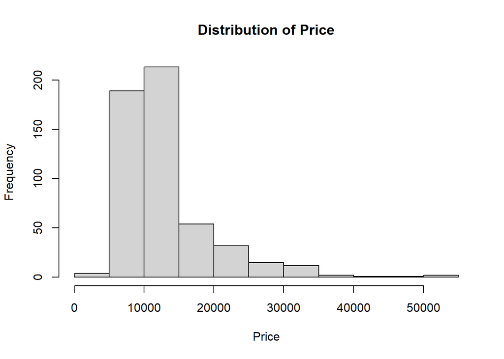

```r
# Summary statistics for numerical variables
summary_stats <- Hoteldata %>%
  select(Price, ReviewsCount, Rating) %>%
  summary()
# Histograms for numerical variables
hist_price <- hist(Hoteldata$Price, main = "Distribution of Price", xlab = "Price")
```

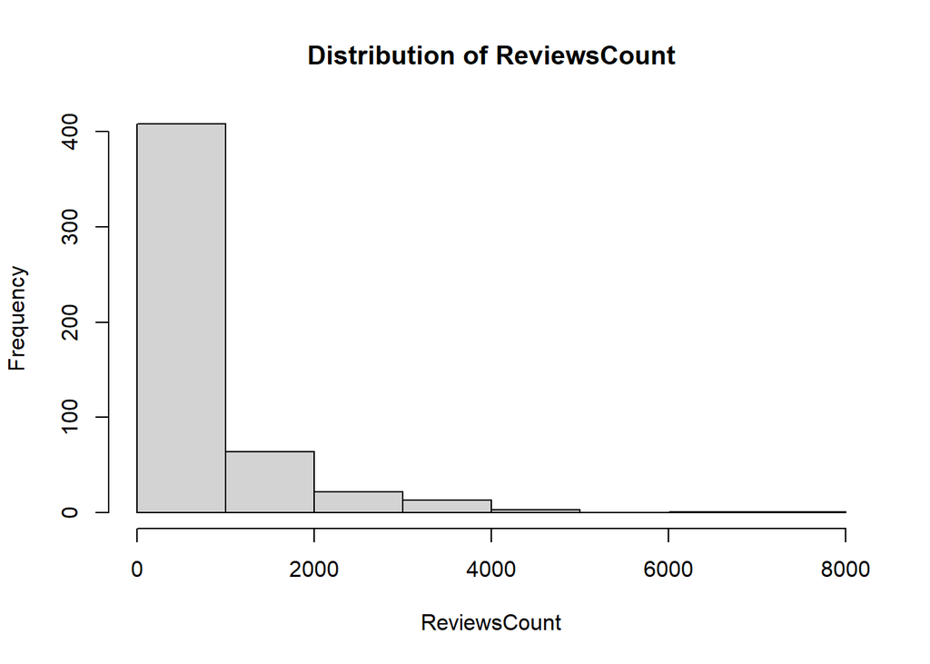

```r
hist_reviews <- hist(Hoteldata$ReviewsCount, main = "Distribution of ReviewsCount", xlab = "ReviewsCount")
```

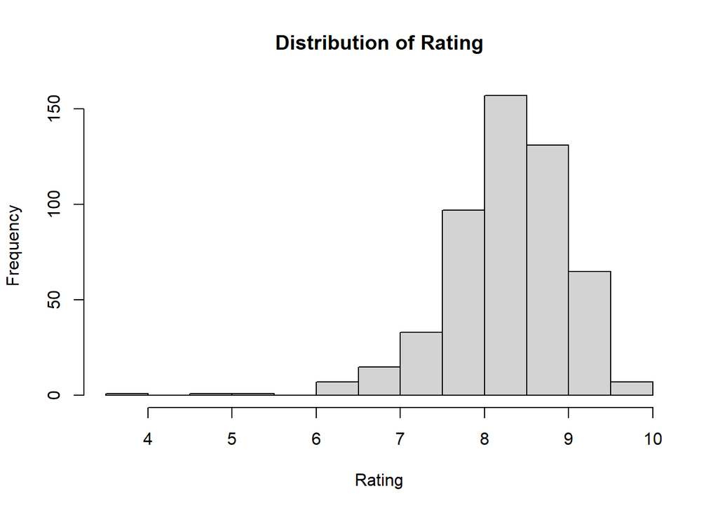

```r
hist_rating <- hist(Hoteldata$Rating, main = "Distribution of Rating", xlab = "Rating")
```

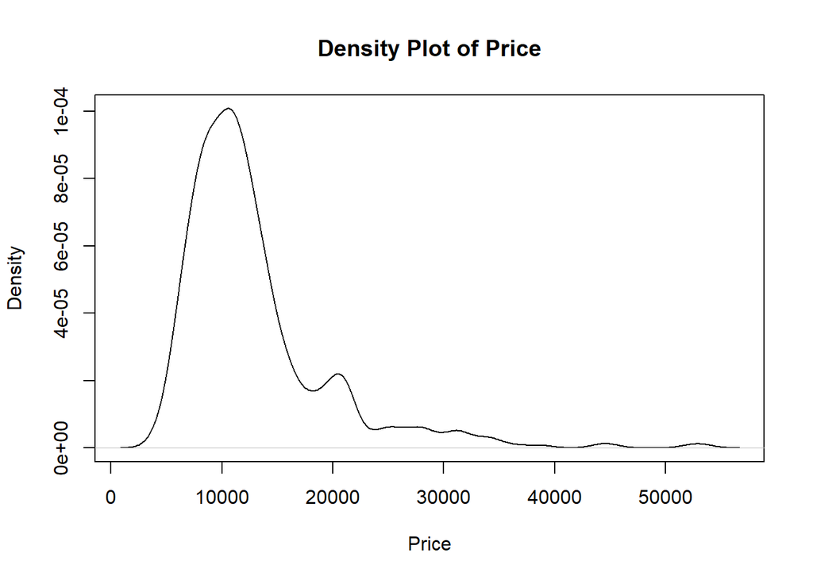

```r
# Density plots for numerical variables
density_price <- density(Hoteldata$Price)
plot(density_price, main = "Density Plot of Price", xlab = "Price")
```

```r
#Measures of relationship
# Check for missing values in 'Price' and 'Rating'
missing_values <- sum(is.na(Hoteldata$Price) | is.na(Hoteldata$Rating))
```

### Preprocessing and Data Transformation (Lab 3 and 4)

Milestone 2 requires addressing issues related to preprocessing and data transformation. This includes confirming the presence of missing values, data imputation, and data transformation. In our BI project, preprocessing involves handling missing values and transforming raw data into meaningful insights for effective customer segmentation.

```r
# Check for missing values in the entire dataset
missing_values <- colSums(is.na(Hoteldata))

# Display the columns with missing values (if any)
print(names(missing_values[missing_values > 0]))
```

```
## [1] "ReviewsCount" "Rating"       "State"
```

```r
# Identify numeric columns with missing values
numeric_cols_with_missing <- names(Hoteldata)[sapply(Hoteldata, is.numeric) & colSums(is.na(Hoteldata)) > 0]

# Mean imputation for each numeric column with missing values
for (col in numeric_cols_with_missing) {
  mean_val <- mean(Hoteldata[[col]], na.rm = TRUE)
  Hoteldata[[col]][is.na(Hoteldata[[col]])] <- mean_val
}
```

### Training the Model (Lab 5-8)

```r
library(caret)
# Set seed for reproducibility
set.seed(123)

# Specifying the proportion of data to be used for testing/validation (In this case; 80% training, 20% testing)
split_index <- createDataPartition(Hoteldata$Price, p = 0.8, list = FALSE)

# Create training set
training_data <- Hoteldata[split_index, ]

# Create testing set
testing_data <- Hoteldata[-split_index, ]

# Check dimensions of training set
dim(training_data)
```

```
## [1] 421   9
```

```r
# Check dimensions of testing set
dim(testing_data)
```

```
## [1] 104   9
```

```r
set.seed(123)
boot_means <- replicate(1000, mean(sample(Hoteldata$Price, replace = TRUE)))
# Confidence interval for the mean
mean_ci <- quantile(boot_means, c(0.025, 0.975))
set.seed(123)
boot_medians <- replicate(1000, median(sample(Hoteldata$Price, replace = TRUE)))
# Confidence interval for the median
median_ci <- quantile(boot_medians, c(0.025, 0.975))

# Bootstrap for standard deviation
set.seed(123)
boot_sds <- replicate(1000, sd(sample(Hoteldata$Price, replace = TRUE)))
# Confidence interval for the standard deviation
sd_ci <- quantile(boot_sds, c(0.025, 0.975))
```

### Hyper-Parameter Tuning and Ensembles (Lab 9-11)

Milestone 4 emphasizes hyper-parameter tuning and ensembles. The project aligns with this by considering methods like random/grid/manual search and exploring bagging/boosting/stacking ensembles for optimizing the model’s performance.

```r
set.seed(123)  # for reproducibility
trainIndex <- createDataPartition(Hoteldata$Price, p = 0.8,
                                  list = FALSE,
                                  times = 1)
train_data <- Hoteldata[trainIndex, ]
test_data  <- Hoteldata[-trainIndex, ]
```

### Consolidation (Lab 12-15)

Milestone 5 focuses on consolidation, utilizing Plumber API to access the model and consuming its output on business-facing and customer-facing dashboards. This ensures the seamless integration of the developed model into the broader business framework, enhancing decision-making and customer satisfaction.